# DATA EXPLORATION ON HFS SERVICE DATA

### Reading the HFS Service Data and obtaining the head of it.

```r
library(ggplot2)
serdat <- read.csv("HFS Service Data.csv")
head(serdat,20)
```

```
##    gender  program_name              program_type
## 1    Male Mental Health Counseling and Prevention
## 2  Female Mental Health Counseling and Prevention
## 3  Female Mental Health Counseling and Prevention
## 4  Female Mental Health Counseling and Prevention
## 5  Female Mental Health Counseling and Prevention
## 6  Female Mental Health Counseling and Prevention
## 7  Female Mental Health Counseling and Prevention
## 8  Female Mental Health Counseling and Prevention
## 9  Female Mental Health Counseling and Prevention
## 10 Female Mental Health Counseling and Prevention
## 11 Female Mental Health Counseling and Prevention
## 12 Female Mental Health Counseling and Prevention
## 13 Female Mental Health Counseling and Prevention
## 14 Female Mental Health Counseling and Prevention
```

[output cut: 258 more lines]

### 1 Two Scatter plots of two different variables, properly labelled

##### a) Scatter plot of RecordID vs Application Status

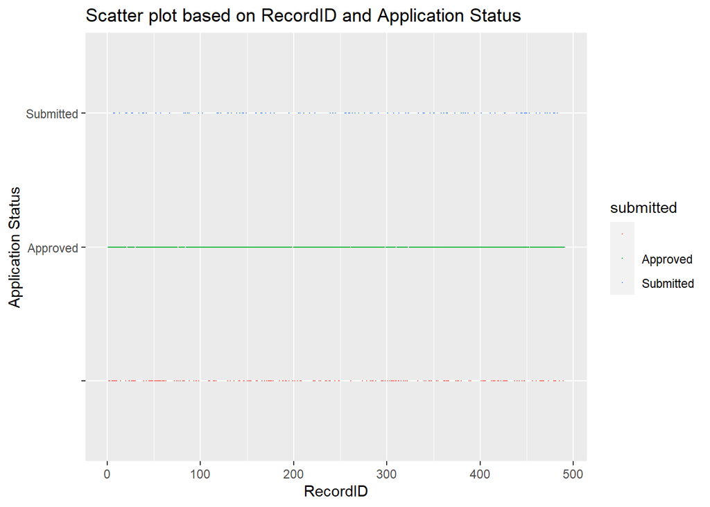

```r
ggplot(serdat, aes(x =recordID , y =submitted,color = submitted)) + geom_point(size=0.1)+
labs(x="RecordID", y="Application Status", title = "Scatter plot based on RecordID and Application Status")
```

###### Observations :

- From the above Scatter plot we can see the status of submitted and Approved applications for different record ids.
- Apart from those two, we also have another coloumn for ‘Blank’ status. This is where data cleaning is required. We can clean the data based on the columns duration and actual_date.

##### b) Scatter plot of Age vs Program

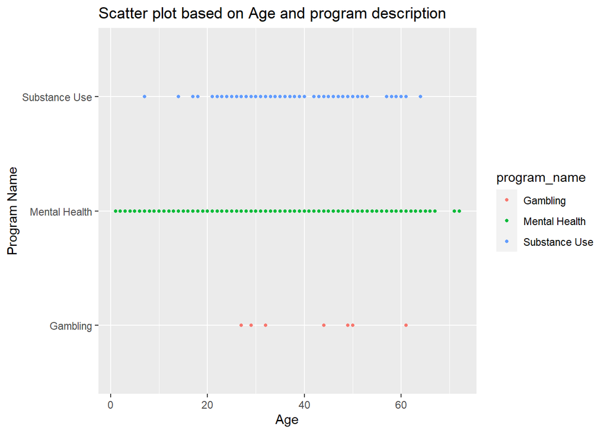

```r
s2 <- ggplot(serdat, aes(x =age , y =program_name,color = program_name)) + geom_point(size=1)+
  labs(x="Age", y="Program Name", title = "Scatter plot based on Age and program description")
s2
```

###### Observations :

- The above scatter plot is between Age and Program Name.
- From the above data we can see that the program Mental health is having people of all ages enrolled in it.
- For the substance use we can see that the most people of age above 21 are enrolling in it, the interesting point here is there are people of age below 21 involving in substance use which is illegal in USA.
- For gambling, people of age around 30 and 50 are enrolling.

### 2 One faceted plot of two variables, properly labelled

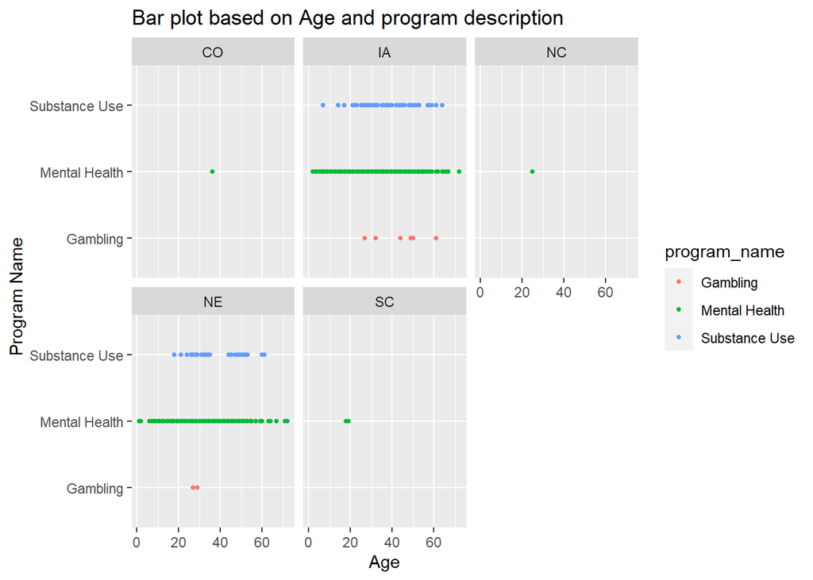

```r
ggplot(serdat, aes(x =age , y =program_name , color= program_name))+ geom_point(size = 1) +
facet_wrap(~state)+labs(x="Age", y="Program Name", title = "Bar plot based on Age and program description")
```

###### Observations :

- The above plot is between Age and Program Name which is same as 1b but faceted by State.
- From this plot we can observe that the people from states SC, CO and NC are involving only in Mental health programs.
- The patients in NE of age below 21 are more than in IA.
- Among all the three programs, gambling service is being used less in all the states.

### 3 One bar chart, properly labeled

##### Bar chart of Count of patients w.r.t States

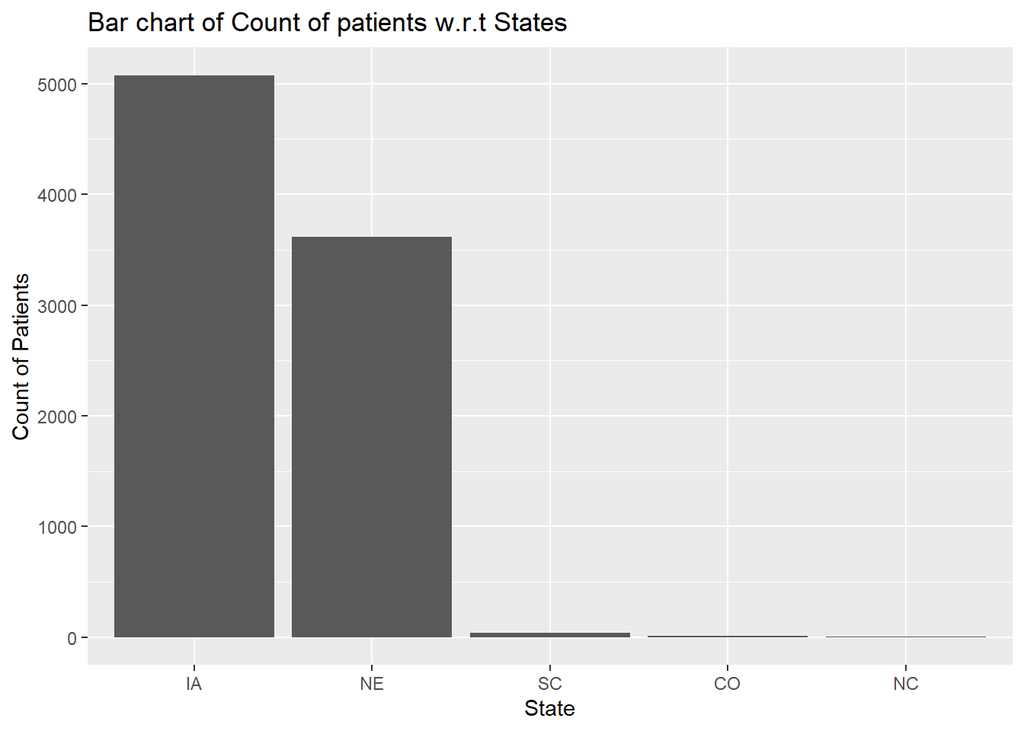

```r
serdat$state <- factor(serdat$state, levels=c("IA", "NE", "SC", "CO", "NC"))
ggplot(serdat, aes(x=state))+ geom_bar(Width = 1)+
labs(x="State", y="Count of Patients", title = 'Bar chart of Count of patients w.r.t States')
```

###### Observations :

- The above graph is between state and count of patients. In this, we can see the number of people enrolling state wise.
- In this graph, we can see the states having patients of high count on the left and of low count on the right.
- The order of enrollments based on state is as follows : IA, NE, SC Co, NC (high to low).